# STAT3064: Assigmment 1

1. 1. Why is it important to describe the mathematical model we want to simulate from and why should one not automatically choose the Gaussian model for a simulation?

      It is important to describe the mathematical model we want to simulate from because we will require to use that model to estimate/predict trends and patterns if we find that the model that has been described demonstrates simulations which closely match the observed experimental results.

      When selecting a mathematical model to perform simulations from, one must not automatically choose a Gaussian model to analyse, as it is unlikely that all experimental contexts will be producing trends which can be accurately described by a Gaussian Model. Examples of this may include a growth/decay context which may be better suited by a exponential model, or current-day COVID cases being better represented by a logistical model.
   2. Give two reasons why simulations should be reproducible.
      1. Investigation / Research may be progeressed in an efficient manner, and the reproducibility will allow for the simulation to be re-used or compared with different simulations to evaluate effectiveness of a model.
      2. To check and verify the validty of the simulations by an external party. This emerges from having the simulation in a reproducible state, with the relevant steps and assumptions documented, which can be critically examined to review validity.
   3. Give details of the variance calculation var($W_2$) for Example 4.2 similar to those for var($W_1$).

      var($W_2$) = var($n_2 ^T$*X*) = var($n_{21}$**X**$_1$ + $n_{22}$**X**$_2$)

      = $n_{21}^2$var(**X**$_1$) + $n_{22}^2$var(**X**$_2$) + 2$n_{21}n_{22}$ * cov(**X**$_1$, **X**$_2$)

      = 0.31$^2$ * 2.4 + 0.95$^2$ * 1 + 2 * 0.31 * 0.95 * (-0.5)

      = **0.84**
2. Consider the aircraft data with the logged variables as in Question 2 of Computer Lab 1. Divide the data into the three period groups. We are interested in comparing changes that occur over time.

   Setup working environment

```r
rm(list = ls())

if (!is.null(sessionInfo()$otherPkgs)) {
  invisible(
    lapply(paste0('package:', names(sessionInfo()$otherPkgs)),
           detach, character.only=TRUE, unload=TRUE)
  )
}

options(stringsAsFactors = FALSE)

library(ggplot2)
library(tidyverse)
library(MASS)
library(GGally)
setwd('C:/Users/aliye/Documents/STAT3064/Assignment 1')

aircraft = read.csv('aircraft.csv')
```

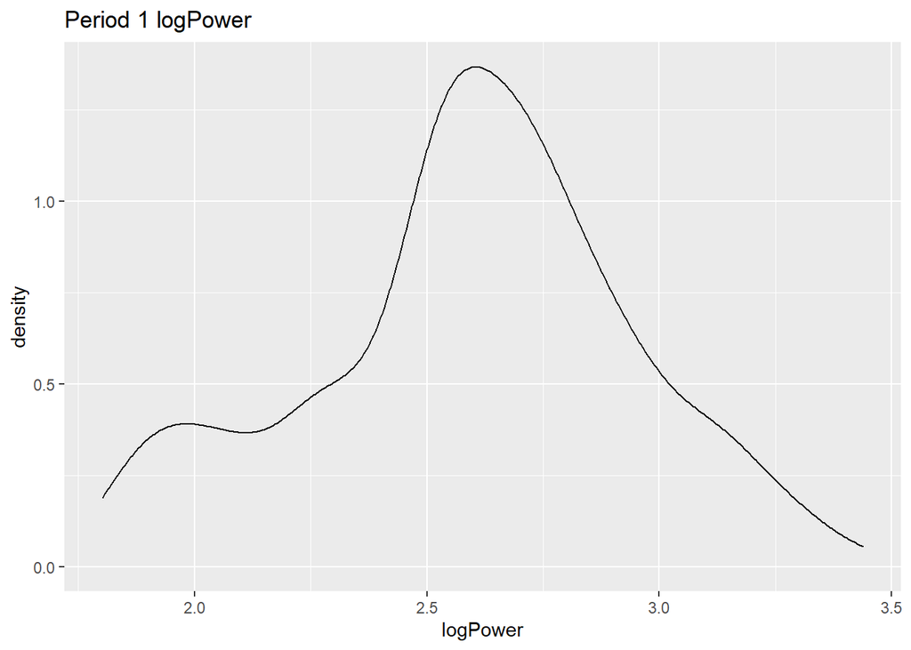

```r
logPower = log10(aircraft$Power)
logSpan = log10(aircraft$Span)
logLength = log10(aircraft$Length)
logWeight = log10(aircraft$Weight)
logSpeed = log10(aircraft$Speed)
logRange = log10(aircraft$Range)

Period = as.factor(aircraft$Period)

Year= aircraft$Year

log_aircraft = data.frame(Year, Period, logPower, logSpan, logLength, logWeight, logSpeed, logRange)

aircraft.per1 = filter( log_aircraft, Period == "1" )
aircraft.per2 = filter( log_aircraft, Period == "2" )
aircraft.per3 = filter( log_aircraft, Period == "3" )

# For Period == 1 #
ggplot( aircraft.per1, aes(logPower)  ) + geom_density() + ggtitle("Period 1 logPower")
```

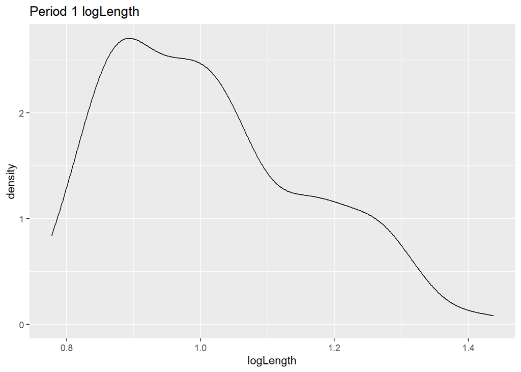

```r
ggplot( aircraft.per1, aes(logLength)  ) + geom_density() + ggtitle("Period 1 logLength")
```

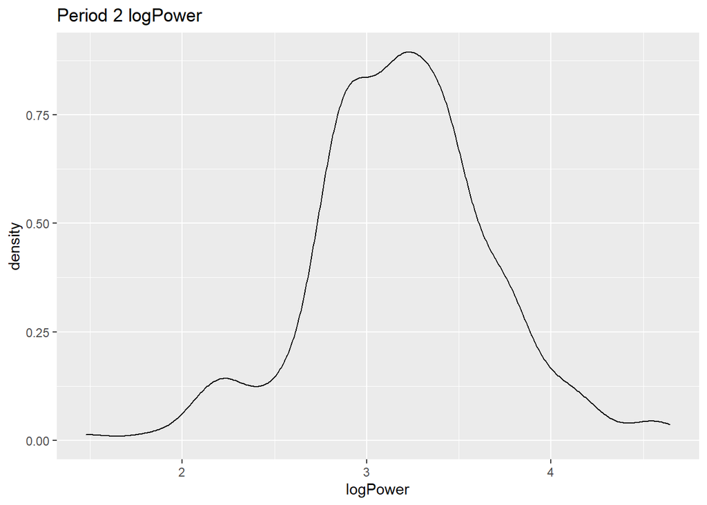

```r
# For Period == 2 #
ggplot( aircraft.per2, aes(logPower)  ) + geom_density() + ggtitle("Period 2 logPower")
```

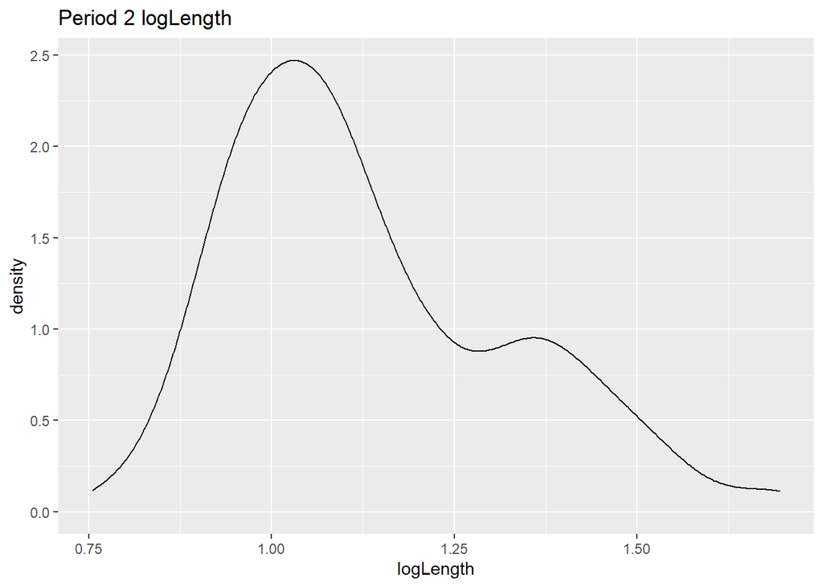

```r
ggplot( aircraft.per2, aes(logLength)  ) + geom_density() + ggtitle("Period 2 logLength")
```

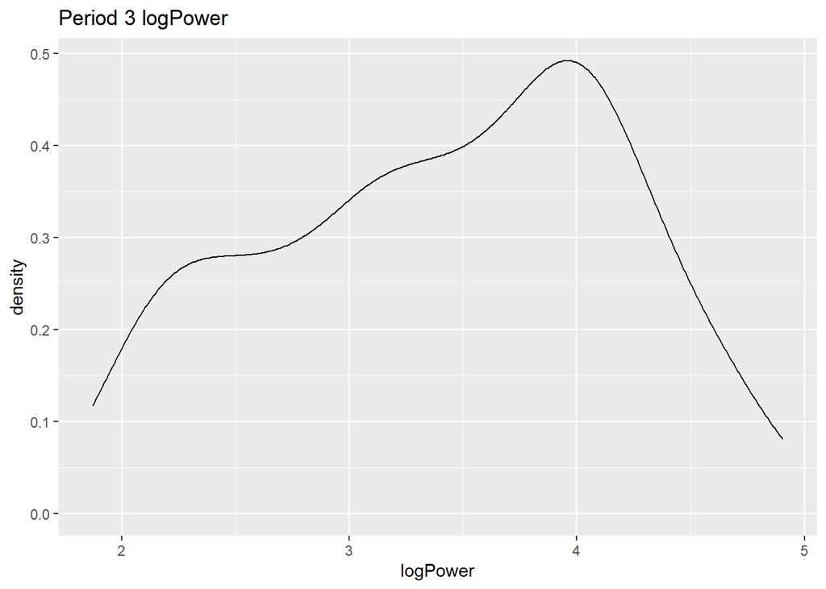

```r
# For Period == 3 #
ggplot( aircraft.per3, aes(logPower)  ) + geom_density() + ggtitle("Period 3 logPower")
```

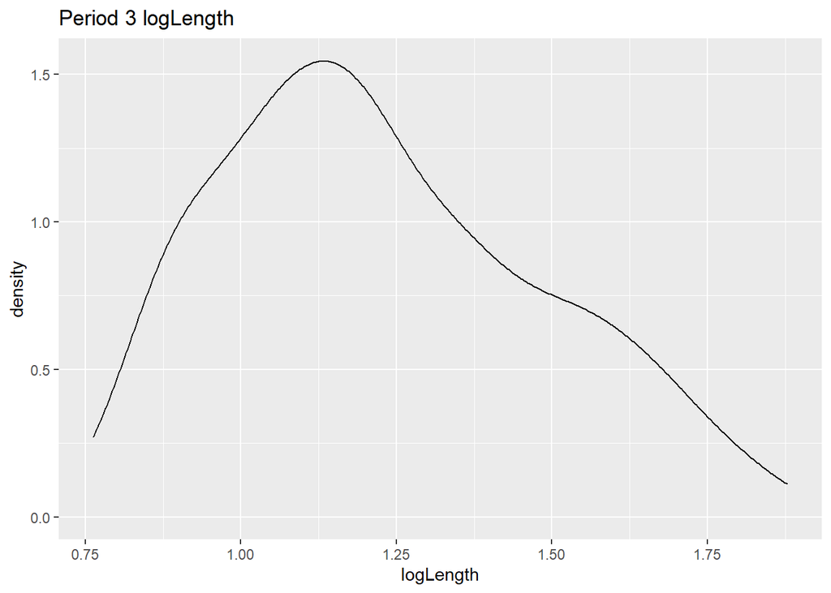

```r
ggplot( aircraft.per3, aes(logLength)  ) + geom_density() + ggtitle("Period 3 logLength")
```

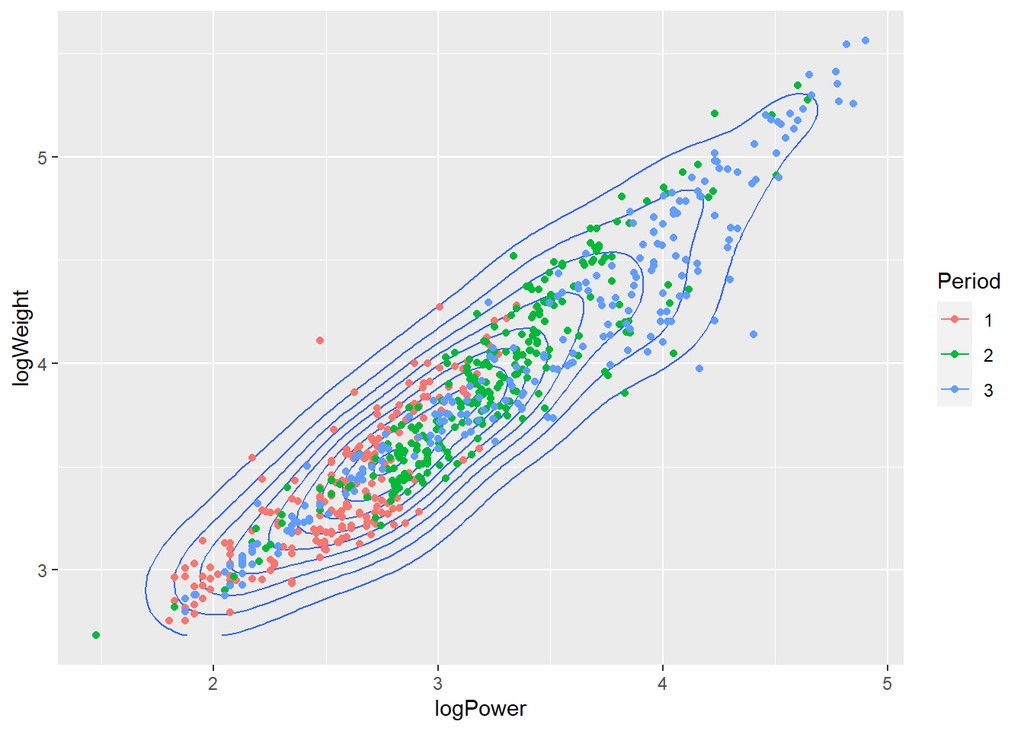

```r
ggplot( log_aircraft, aes( logPower, logWeight )) + geom_density_2d( ) + geom_point( aes( colour = Period))
```

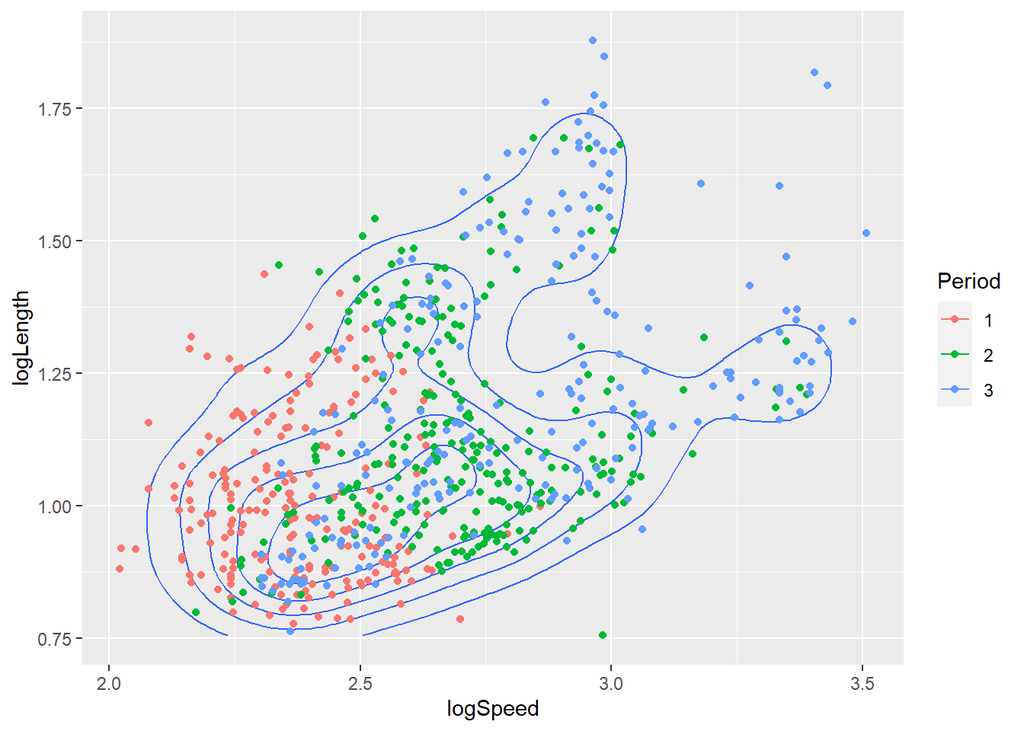

```r
ggplot( log_aircraft, aes( logSpeed, logLength )) + geom_density_2d( ) + geom_point( aes( colour = Period))
```